# Лабораторная работа №4

Основы информационной безопасности

Иванов Сергей Владимирович, НПИбд-01-23

Российский университет дружбы народов, Москва, Россия

20 марта 2024

## Цель работы

Получение практических навыков работы в консоли с расширенными атрибутами файлов.

# Выполнение работы

## Определение атрибутов

От имени пользователя guest определим расширенные атрибуты файла /home/guest/dir1/file1 командой lsattr /home/guest/dir1/file1 (рис. 1)

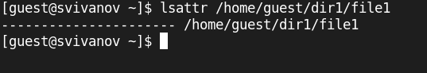

Определение атрибутов

## Попытка установить атрибут

Попробуем установить на файл /home/guest/dir1/file1 расширенный атрибут a от имени пользователя guest. В ответ получаем отказ от выполнения операции (рис. 3).

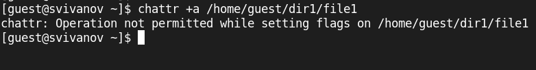

Попытка установить атрибут

## Установка атрибута

Повысим свои права с помощью команды su. Установим расширенный атрибут a на файл /home/guest/dir1/file1 от имени суперпользователя (рис. 4).

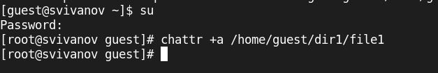

Установка атрибута

## Проверка атрибута

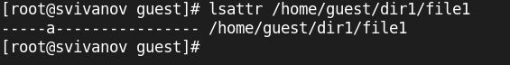

Проверка атрибута

## Дозапись в файл

Выполним дозапись в файл file1 слова «test» командой echo “test” >> /home/guest/dir1/file1 После этого выполним чтение файла file1 (рис. 6).

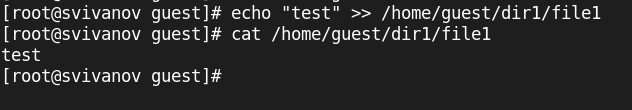

Дозапись в файл

## Попытка удаления

Попробуем удалить файл file1. Удаление запрещено. (рис. 7).

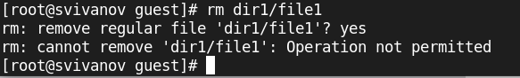

Попытка удаления

## Попытка переименования

Попробуем переименовать файл. Переименование запрещено. (рис. 8).

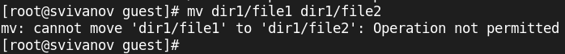

Попытка переименования

## Попытка установки прав

Попробуем с помощью команды chmod установить права 000 на file1. Операция запрещена. (рис. 9).

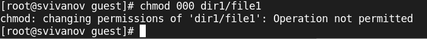

Попытка установки прав

## Снятие расширенного атрибута

Снимем расширенный атрибут a с файла /home/guest/dirl/file1 от имени суперпользователя (рис. 10).

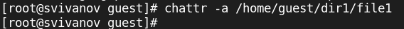

Снятие расширенного атрибута

## Повторение операций

Повторим операции, которые ранее не удавалось выполнить. Теперь все операции разрешены. (рис. 11).

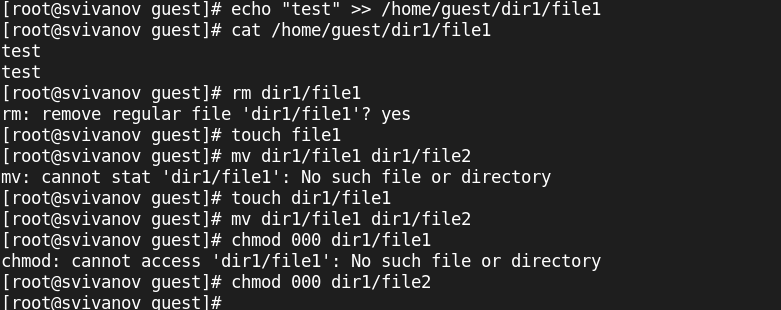

Повторение операций

## Замена атрибута

Заменим атрибут ‘a’ атрибутом ‘i’ . (рис. 12).

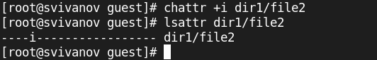

Замена атрибута

## Повторение операций

Повторим все действия. Видим, что все действия запрещены кроме чтения файла. (рис. 13).

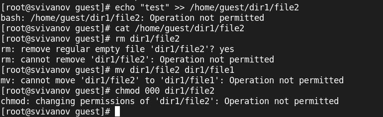

Повторение операций

# Вывод

## Вывод

В ходе работы были получены практические навыки работы в консоли с расширенными атрибутами файлов.